# Algae数据分析

陈建杰（2022190065）

2024-11-28

## 2.1 数据说明

这个问题涉及两个主要的数据集。第一个数据集包含200个水样的数据。更准确地说，每个观察值实际上是从同一条河流在同一季节内、为期3个月期间收集的多个水样的汇总。

每个观察值包含11个变量的信息。其中三个变量是名义变量，描述了水样汇总时所处的季节、河流的大小以及流速。剩下的八个变量是不同化学参数的测量值，这些参数是从构成汇总的水样中得出的，分别为：

- 最高的pH值
- 最低的氧气($O_2$)值
- 氯化物($Cl$)的平均值
- 硝酸盐($NO_3^{-}$)的平均值
- 铵($NH_4^{+}$)的平均值
- 正磷酸盐($PO_4^{3-}$)的平均值
- 总磷酸盐($PO_4$)的平均值
- 叶绿素的平均值

与这些参数相关的还有七个有害藻类的频率值，分别是从相应的水样中找到的不同有害藻类的频率，但没有提供所识别藻类的名称。

第二个数据集包含140个额外的观察值。它的基本结构与第一个数据集相同，但不包含关于七个有害藻类频率的信息。这些额外的观察值可以视为一种测试集。我们研究的主要目标是预测这些有害藻类的频率。

请跟随下面的引导完成本数据的分析。下面文档中大部分地方都给出了结果，请同学们写代码得到相应的结果。

## 2.2 加载数据到R

```r
algae <- read.table("E:\\桌面\\r\\w13周上机\\algae.txt", col.names=c('season', 'size', 'speed', 'mxPH', 'mn02', 'C1', 'NO3', 'NH4', 'oP04', 'P04', 'Chla', 'a1', 'a2', 'a3', 'a4', 'a5', 'a6', 'a7'), na.strings = c('XXXXXXX'))
```

## 2.3 数据探索和可视化

### 编写代码得到如下描述性统计概要。

```r
summary(algae)
```

```
##     season              size              speed                mxPH
##  Length:200         Length:200         Length:200         Min.   :5.600
##  Class :character   Class :character   Class :character   1st Qu.:7.700
##  Mode  :character   Mode  :character   Mode  :character   Median :8.060
##                                                           Mean   :8.012
##                                                           3rd Qu.:8.400
##                                                           Max.   :9.700
##                                                           NA's   :1
##       mn02              C1               NO3              NH4
##  Min.   : 1.500   Min.   :  0.222   Min.   : 0.050   Min.   :    5.00
##  1st Qu.: 7.725   1st Qu.: 10.981   1st Qu.: 1.296   1st Qu.:   38.33
##  Median : 9.800   Median : 32.730   Median : 2.675   Median :  103.17
##  Mean   : 9.118   Mean   : 43.636   Mean   : 3.282   Mean   :  501.30
##  3rd Qu.:10.800   3rd Qu.: 57.824   3rd Qu.: 4.446   3rd Qu.:  226.95
##  Max.   :13.400   Max.   :391.500   Max.   :45.650   Max.   :24064.00
##  NA's   :2        NA's   :10        NA's   :2        NA's   :2
##       oP04             P04              Chla               a1
##  Min.   :  1.00   Min.   :  1.00   Min.   :  0.200   Min.   : 0.00
##  1st Qu.: 15.70   1st Qu.: 41.38   1st Qu.:  2.000   1st Qu.: 1.50
##  Median : 40.15   Median :103.29   Median :  5.475   Median : 6.95
##  Mean   : 73.59   Mean   :137.88   Mean   : 13.971   Mean   :16.92
##  3rd Qu.: 99.33   3rd Qu.:213.75   3rd Qu.: 18.308   3rd Qu.:24.80
##  Max.   :564.60   Max.   :771.60   Max.   :110.456   Max.   :89.80
##  NA's   :2        NA's   :2        NA's   :12
##        a2               a3               a4               a5
##  Min.   : 0.000   Min.   : 0.000   Min.   : 0.000   Min.   : 0.000
##  1st Qu.: 0.000   1st Qu.: 0.000   1st Qu.: 0.000   1st Qu.: 0.000
##  Median : 3.000   Median : 1.550   Median : 0.000   Median : 1.900
##  Mean   : 7.458   Mean   : 4.309   Mean   : 1.992   Mean   : 5.064
##  3rd Qu.:11.375   3rd Qu.: 4.925   3rd Qu.: 2.400   3rd Qu.: 7.500
##  Max.   :72.600   Max.   :42.800   Max.   :44.600   Max.   :44.400
##
##        a6               a7
##  Min.   : 0.000   Min.   : 0.000
##  1st Qu.: 0.000   1st Qu.: 0.000
##  Median : 0.000   Median : 1.000
##  Mean   : 5.964   Mean   : 2.495
##  3rd Qu.: 6.925   3rd Qu.: 2.400
##  Max.   :77.600   Max.   :31.600
##
```

### 画出如下关于列`mxPH`的直方图。

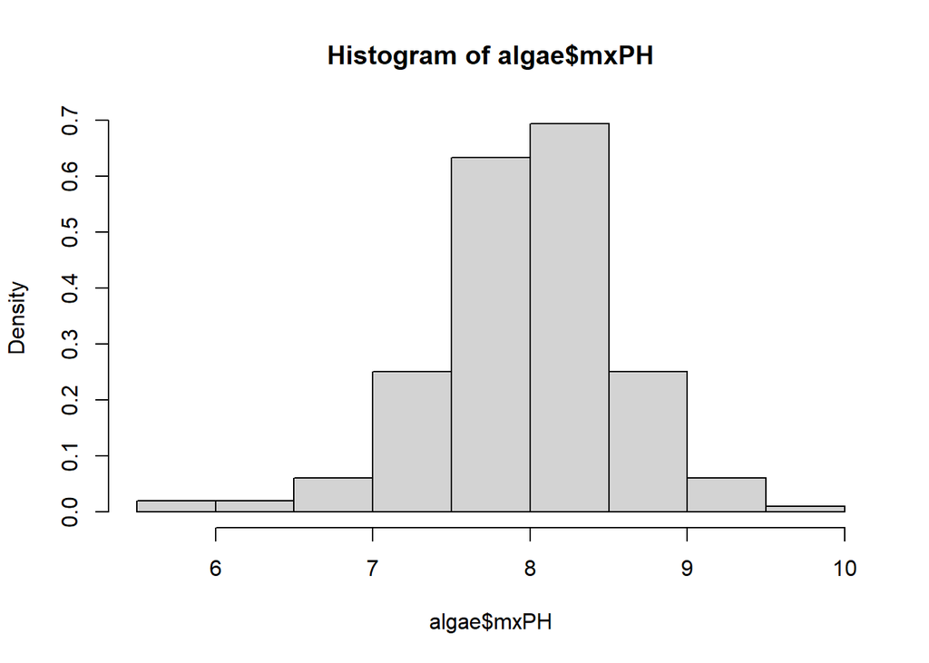

```r
hist(algae$mxPH,breaks = 10,freq = FALSE)
```

### 使用QQ图判断是否服从正态分布

QQ图（Quantile-Quantile plot）是用来判断数据是否服从正态分布的常用图形工具。通过将数据的分位数与理论正态分布的分位数进行对比，QQ图能够直观地展示数据与正态分布的差异。以下是使用QQ图判断数据是否服从正态分布的步骤和要点：

1. 横轴和纵轴的定义
- 横轴：理论正态分布的分位数。
- 纵轴：实际数据的分位数。
2. 绘制QQ图
- 将样本数据按从小到大的顺序排列。
- 根据样本数据的分位数，找到与之相对应的标准正态分布的分位数。
- 在QQ图上绘制这些点，横轴为正态分布分位数，纵轴为样本数据的分位数。
3. 判断标准
- 接近直线：如果数据点大致落在QQ图中的一条直线上，那么说明数据与正态分布较为接近，即数据可能服从正态分布。
- 明显偏离直线：如果数据点出现明显的弯曲或偏离直线，说明数据偏离正态分布。例如：
  - 尾部偏离（重尾或轻尾）：如果在QQ图的两端（尾部）数据点明显偏离直线，说明数据的 * 分布可能存在重尾（厚尾）或轻尾的现象。 中间偏离：如果数据在中间位置偏离直线，可能表示数据的偏态，或者数据集中于某个范围。

画出`mxPH`的直方图和QQ图，如下。可能需要用到的函数包括`rug`，`jitter`,包`car`中的函数`qqPlot`. 请查看帮助文档。

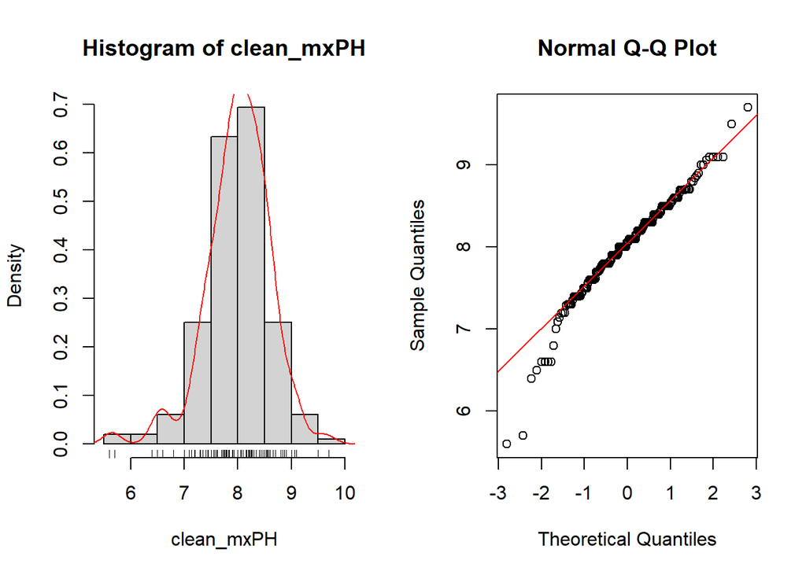

```r
layout(matrix(c(1, 2), nrow = 1, ncol = 2))
#直方图
clean_mxPH <- na.omit(algae$mxPH)
hist(clean_mxPH, breaks = 10, freq = FALSE)
density_curve <- density(clean_mxPH)
lines(density_curve, col = "red")
rug(clean_mxPH)
#qq
qqnorm(jitter(algae$mxPH))
qqline(jitter(algae$mxPH),col = "red")
```

### 画出如下`oP04`的箱线图，可能用到的函数`rug`, `jitter`。请查看帮助文档。

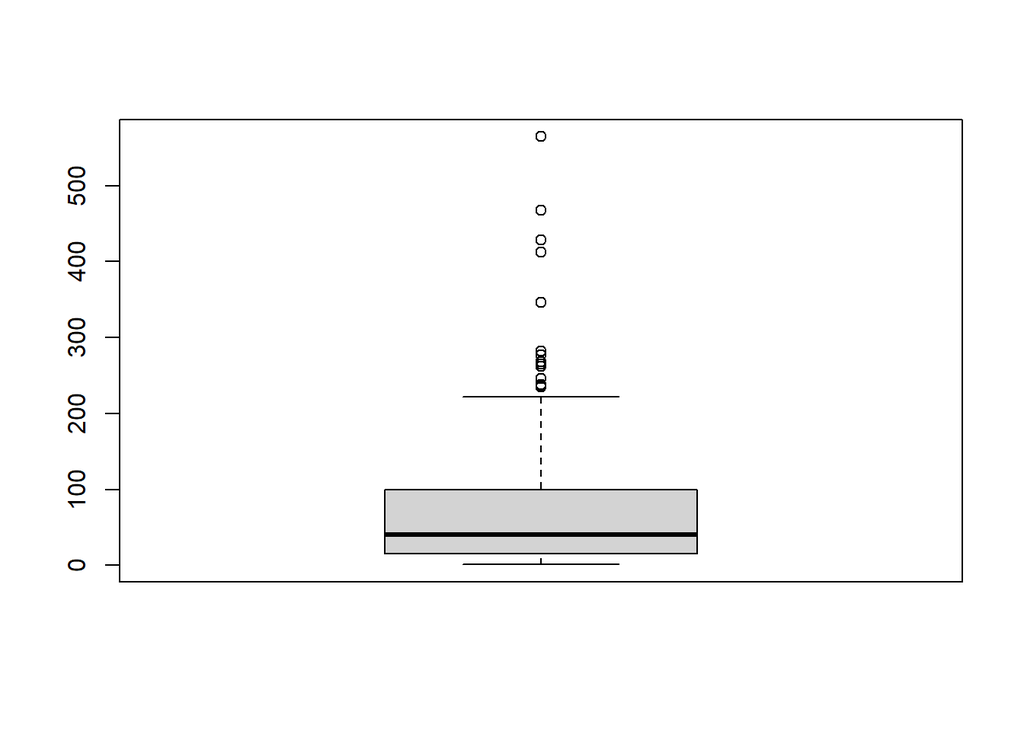

```r
oP04 <- na.omit(algae$oP04)
boxplot(jitter(oP04))
```

## 2.4 数据缺失

### 请计算至少包括一个缺失值的观测点个数。

```r
sum(rowSums(is.na(algae))>0)
```

```
## [1] 16
```

### 计算每一行观测点的NA数量。

```r
rowSums(is.na(algae))
```

```
##   [1] 0 0 0 0 0 0 0 0 0 0 0 0 0 0 0 0 0 0 0 0 0 0 0 0 0 0 0 1 0 0 0 0 0 0 0 0 0
##  [38] 1 0 0 0 0 0 0 0 0 0 1 0 0 0 0 0 0 2 2 2 2 2 2 2 6 1 0 0 0 0 0 0 0 0 0 0 0
##  [75] 0 0 0 0 0 0 0 0 0 0 0 0 0 0 0 0 0 0 0 0 0 0 0 0 0 0 0 0 0 0 0 0 0 0 0 0 0
## [112] 0 0 0 0 1 0 0 0 0 0 0 0 0 0 0 0 0 0 0 0 0 0 0 0 0 0 0 0 0 0 0 0 0 0 0 0 0
## [149] 0 0 0 0 0 0 0 0 0 0 0 0 1 0 0 0 0 0 0 0 0 0 0 0 0 0 0 0 0 0 0 0 0 0 0 1 0
## [186] 0 0 0 0 0 0 0 0 0 0 0 0 0 6 0
```

### 在`algae`中去除NA数量大于5的行。

```r
algae <- algae[rowSums(is.na(algae)) <= 5, ]
```

### 列`mxPH`只包含一个NA，用`mxPH`不包含缺失值的平均值填补`mxPH`的唯一缺失值。

```r
mxPH_mean <- mean(algae$mxPH, na.rm = TRUE)
algae$mxPH[is.na(algae$mxPH)] <- mxPH_mean
```

### 请用列`Chla`不包含缺失值的中位数填补列`Chla`所有的缺失值。

```r
Chla_median <- median(algae$Chla, na.rm = TRUE)
algae$Chla[is.na(algae$Chla)] <- Chla_median
```

请注意，到现在为止，数据`algae`的列`mxPH`, `Chla`都不包含缺失值了。

### 计算`algae`的4到11列的Pearson相关关系，注意计算时不能使用缺失值。可以查看`cor`的帮助文档，可以设置相关参数。

```r
cor_matrix <- cor(algae[, 4:11], use = "complete.obs")
cor_matrix
```

```
##             mxPH        mn02          C1        NO3         NH4        oP04
## mxPH  1.00000000 -0.08995507  0.12806488 -0.1769637 -0.15288154  0.07951148
## mn02 -0.08995507  1.00000000 -0.27592563  0.1006903 -0.08283552 -0.40269754
## C1    0.12806488 -0.27592563  1.00000000  0.2205048  0.06997017  0.38679935
## NO3  -0.17696372  0.10069032  0.22050483  1.0000000  0.72415177  0.14189472
## NH4  -0.15288154 -0.08283552  0.06997017  0.7241518  1.00000000  0.22180971
## oP04  0.07951148 -0.40269754  0.38679935  0.1418947  0.22180971  1.00000000
## P04   0.08266826 -0.47528739  0.45462947  0.1689841  0.20249650  0.91236866
## Chla  0.41173156 -0.14002959  0.14975472  0.1514221  0.09347428  0.11319877
##              P04        Chla
## mxPH  0.08266826  0.41173156
## mn02 -0.47528739 -0.14002959
## C1    0.45462947  0.14975472
## NO3   0.16898413  0.15142209
## NH4   0.20249650  0.09347428
## oP04  0.91236866  0.11319877
## P04   1.00000000  0.25514838
## Chla  0.25514838  1.00000000
```

可以使用函数`symnum`更好的显示相关关系矩阵的结果。

```r
symnum(cor_matrix)
```

```
##      mP m0 C1 NO NH o P Ch
## mxPH 1
## mn02    1
## C1         1
## NO3           1
## NH4           ,  1
## oP04    .  .        1
## P04     .  .        * 1
## Chla .                  1
## attr(,"legend")
## [1] 0 ' ' 0.3 '.' 0.6 ',' 0.8 '+' 0.9 '*' 0.95 'B' 1
```

### 以`P04`为因变量，`oP04`为自变量建立简单线性回归模型。可能用到函数`lm`分，请查看帮助文档。

```r
model <- lm(P04 ~ oP04, data = algae)
summary(model)
```

```
##
## Call:
## lm(formula = P04 ~ oP04, data = algae)
##
## Residuals:
##     Min      1Q  Median      3Q     Max
## -110.12  -36.34  -12.68   23.26  216.98
##
## Coefficients:
##             Estimate Std. Error t value Pr(>|t|)
## (Intercept)   42.897      4.808   8.922 3.34e-16 ***
## oP04           1.293      0.041  31.535  < 2e-16 ***
## ---
## Signif. codes:  0 '***' 0.001 '**' 0.01 '*' 0.05 '.' 0.1 ' ' 1
##
## Residual standard error: 52.37 on 195 degrees of freedom
##   (因为不存在，1个观察量被删除了)
## Multiple R-squared:  0.8361, Adjusted R-squared:  0.8352
## F-statistic: 994.5 on 1 and 195 DF,  p-value: < 2.2e-16
```

### 使用函数`na.omit`去除当前的`algae`的至少包含一个NA的行。

```r
algae <- na.omit(algae)
```

## 回归模型（选做）

### 多元线性回归, 以`a1`为因变量，前11列为自变量建立线性回归模型。使用`summary`查看模型的结果。可能用到函数`lm`分，请查看帮助文档。

```r
model_multiple <- lm(algae$a1 ~., data = algae[, 1:11])
summary(model_multiple)
```

```
##
## Call:
## lm(formula = algae$a1 ~ ., data = algae[, 1:11])
##
## Residuals:
##     Min      1Q  Median      3Q     Max
## -37.576 -10.454  -2.748   6.332  68.186
##
## Coefficients:
##                Estimate Std. Error t value Pr(>|t|)
## (Intercept)  21.3292980 28.3185318   0.753  0.45236
## seasonspring -0.5855722  4.2316320  -0.138  0.89010
## seasonsummer -0.3382463  4.0201450  -0.084  0.93304
## seasonwinter  2.2939334  3.8578204   0.595  0.55288
## sizemedium    3.0524656  3.7054183   0.824  0.41120
## sizesmall     9.0011063  4.0763802   2.208  0.02856 *
## speedlow      1.5741063  4.6615077   0.338  0.73601
## speedmedium  -2.1920063  3.3326572  -0.658  0.51159
## mxPH         -0.2755470  3.3235374  -0.083  0.93402
## mn02          0.7184560  0.6930165   1.037  0.30133
## C1           -0.0337223  0.0328661  -1.026  0.30631
## NO3          -1.5509549  0.5440284  -2.851  0.00489 **
## NH4           0.0017693  0.0009821   1.802  0.07336 .
## oP04         -0.0143849  0.0392473  -0.367  0.71443
## P04          -0.0406373  0.0304991  -1.332  0.18449
## Chla         -0.1132087  0.0809541  -1.398  0.16378
## ---
## Signif. codes:  0 '***' 0.001 '**' 0.01 '*' 0.05 '.' 0.1 ' ' 1
##
## Residual standard error: 17.16 on 172 degrees of freedom
## Multiple R-squared:  0.3391, Adjusted R-squared:  0.2815
## F-statistic: 5.884 on 15 and 172 DF,  p-value: 9.247e-10
```

简答：你能从模型中得到什么结论吗？

### 树模型（选做）

把前3列数据转化为因子型。

```r
algae[, 1:3] <- lapply(algae[, 1:3], as.factor)
```

分类回归树（Classification and Regression Tree, CART）是一种常用的决策树算法，用于解决分类和回归问题。CART模型根据数据的特征递归地将数据集划分成更小的子集，形成一棵二叉树。在每个节点上，CART会选择一个最优的分裂点（特征及其阈值）来最大化子集的纯度。

分类树：用于处理离散的类别标签问题。它通过选择特征的分裂点来最大化每个子节点中的类别纯度。常用的指标有基尼系数（Gini impurity）和信息增益（Entropy）。

回归树：用于处理连续的数值预测问题。它通过选择特征的分裂点来最小化子节点中的方差或平方误差。

关于分类回归树，我们在后续课程中将会学习。在这里，我们先简单使用该模型。

使用包`tree`中的函数`tree`建立回归树。以`a1`为因变量，前11列为自变量建立线性回归模型。使用`summary`查看模型的结果。请查看相关函数代码。

```r
library(tree)
model_tree <- tree(algae$a1 ~., data = algae[, 1:11])
summary(model_tree)
```

```
##
## Regression tree:
## tree(formula = algae$a1 ~ ., data = algae[, 1:11])
## Variables actually used in tree construction:
## [1] "C1"     "season" "P04"    "oP04"   "mn02"   "size"   "NH4"    "NO3"
## Number of terminal nodes:  10
## Residual mean deviance:  149.2 = 26550 / 178
## Distribution of residuals:
##    Min. 1st Qu.  Median    Mean 3rd Qu.    Max.
## -32.110  -3.872  -2.128   0.000   4.846  57.220
```

简答：你能从模型中得到什么结论吗？

残差分布并非完全对称，可能存在一定的偏态情况。